# 21_equal_temperament_fifth_error

## 21_equal_temperament_fifth_error

#### Question

1. When the ratio between two [fundamental frequencies](https://en.wikipedia.org/wiki/Fundamental_frequency) is near 3:2, musicians call the interval a “fifth”, named from playing the first and fifth notes in a classical [diatonic scale](https://en.wikipedia.org/wiki/Diatonic_scale). Somewhat annoyingly, [equal temperament](https://en.wikipedia.org/wiki/Equal_temperament) does not allow for a ratio of exactly 3:2. Some equal temperaments get closer than others. Let’s investigate how close [10 EDO](https://en.wikipedia.org/wiki/Equal_temperament#Various_equal_temperaments) can get to an [exact 3:2 ratio of frequencies](https://en.wikipedia.org/wiki/Just_intonation). We will report the “distance” in cents.

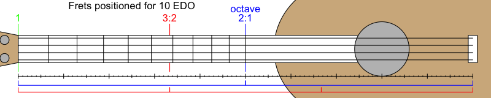

   First, determine the interval (in cents) of an exact 3:2 ratio. (*Notice, the calculation below suggests that a standard 12-EDO system is only ~2 cents away from a perfect 3:2 ratio when playing an interval of 7 [semitones](https://en.wikipedia.org/wiki/Semitone). This is a compelling reason to use [12 EDO](https://en.wikipedia.org/wiki/12_equal_temperament).*)

   $$I_\text{exact} ~=~ 1200\cdot\log_2\left(\frac{3}{2}\right) ~=~ 701.9550009$$

   Determine the best [fret](https://en.wikipedia.org/wiki/Fret) on the 10-EDO guitar to approximate a 3:2 ratio (after playing an open string) by [rounding](https://en.wikipedia.org/wiki/Rounding#Rounding_to_the_nearest_integer) a logarithmic function.

   $$x ~=~ \text{round} \left(10\cdot \log_2\left(\frac{3}{2}\right) \right)$$
   Then, determine the ratio of frequencies between an open string and the $x$th fret on the 10-EDO guitar. The ratio should be near 1.5, but a bit off.

   $$r = 2^{x/10}$$

   Calculate the cents of the interval between the open string and the $x$th fret.

   $$I_{\text{fret}} = 1200 \cdot \log_2(r)$$

   Finally, determine the absolute difference.

   $$\text{answer} = \left|I_{\text{fret}} - I_{\text{exact}}\right|$$

   Your answer can be rounded to the nearest cent.

#### Question

2. When the ratio between two [fundamental frequencies](https://en.wikipedia.org/wiki/Fundamental_frequency) is near 3:2, musicians call the interval a “fifth”, named from playing the first and fifth notes in a classical [diatonic scale](https://en.wikipedia.org/wiki/Diatonic_scale). Somewhat annoyingly, [equal temperament](https://en.wikipedia.org/wiki/Equal_temperament) does not allow for a ratio of exactly 3:2. Some equal temperaments get closer than others. Let’s investigate how close [22 EDO](https://en.wikipedia.org/wiki/Equal_temperament#Various_equal_temperaments) can get to an [exact 3:2 ratio of frequencies](https://en.wikipedia.org/wiki/Just_intonation). We will report the “distance” in cents.

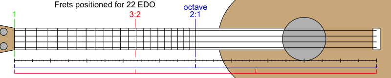

   First, determine the interval (in cents) of an exact 3:2 ratio. (*Notice, the calculation below suggests that a standard 12-EDO system is only ~2 cents away from a perfect 3:2 ratio when playing an interval of 7 [semitones](https://en.wikipedia.org/wiki/Semitone). This is a compelling reason to use [12 EDO](https://en.wikipedia.org/wiki/12_equal_temperament).*)

   $$I_\text{exact} ~=~ 1200\cdot\log_2\left(\frac{3}{2}\right) ~=~ 701.9550009$$

   Determine the best [fret](https://en.wikipedia.org/wiki/Fret) on the 22-EDO guitar to approximate a 3:2 ratio (after playing an open string) by [rounding](https://en.wikipedia.org/wiki/Rounding#Rounding_to_the_nearest_integer) a logarithmic function.

   $$x ~=~ \text{round} \left(22\cdot \log_2\left(\frac{3}{2}\right) \right)$$
   Then, determine the ratio of frequencies between an open string and the $x$th fret on the 22-EDO guitar. The ratio should be near 1.5, but a bit off.

   $$r = 2^{x/22}$$

   Calculate the cents of the interval between the open string and the $x$th fret.

   $$I_{\text{fret}} = 1200 \cdot \log_2(r)$$

   Finally, determine the absolute difference.

   $$\text{answer} = \left|I_{\text{fret}} - I_{\text{exact}}\right|$$

   Your answer can be rounded to the nearest cent.

#### Question

3. When the ratio between two [fundamental frequencies](https://en.wikipedia.org/wiki/Fundamental_frequency) is near 3:2, musicians call the interval a “fifth”, named from playing the first and fifth notes in a classical [diatonic scale](https://en.wikipedia.org/wiki/Diatonic_scale). Somewhat annoyingly, [equal temperament](https://en.wikipedia.org/wiki/Equal_temperament) does not allow for a ratio of exactly 3:2. Some equal temperaments get closer than others. Let’s investigate how close [15 EDO](https://en.wikipedia.org/wiki/Equal_temperament#Various_equal_temperaments) can get to an [exact 3:2 ratio of frequencies](https://en.wikipedia.org/wiki/Just_intonation). We will report the “distance” in cents.

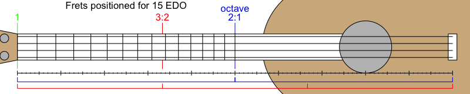

   First, determine the interval (in cents) of an exact 3:2 ratio. (*Notice, the calculation below suggests that a standard 12-EDO system is only ~2 cents away from a perfect 3:2 ratio when playing an interval of 7 [semitones](https://en.wikipedia.org/wiki/Semitone). This is a compelling reason to use [12 EDO](https://en.wikipedia.org/wiki/12_equal_temperament).*)

   $$I_\text{exact} ~=~ 1200\cdot\log_2\left(\frac{3}{2}\right) ~=~ 701.9550009$$

   Determine the best [fret](https://en.wikipedia.org/wiki/Fret) on the 15-EDO guitar to approximate a 3:2 ratio (after playing an open string) by [rounding](https://en.wikipedia.org/wiki/Rounding#Rounding_to_the_nearest_integer) a logarithmic function.

   $$x ~=~ \text{round} \left(15\cdot \log_2\left(\frac{3}{2}\right) \right)$$
   Then, determine the ratio of frequencies between an open string and the $x$th fret on the 15-EDO guitar. The ratio should be near 1.5, but a bit off.

   $$r = 2^{x/15}$$

   Calculate the cents of the interval between the open string and the $x$th fret.

   $$I_{\text{fret}} = 1200 \cdot \log_2(r)$$

   Finally, determine the absolute difference.

   $$\text{answer} = \left|I_{\text{fret}} - I_{\text{exact}}\right|$$

   Your answer can be rounded to the nearest cent.

#### Question

4. When the ratio between two [fundamental frequencies](https://en.wikipedia.org/wiki/Fundamental_frequency) is near 3:2, musicians call the interval a “fifth”, named from playing the first and fifth notes in a classical [diatonic scale](https://en.wikipedia.org/wiki/Diatonic_scale). Somewhat annoyingly, [equal temperament](https://en.wikipedia.org/wiki/Equal_temperament) does not allow for a ratio of exactly 3:2. Some equal temperaments get closer than others. Let’s investigate how close [30 EDO](https://en.wikipedia.org/wiki/Equal_temperament#Various_equal_temperaments) can get to an [exact 3:2 ratio of frequencies](https://en.wikipedia.org/wiki/Just_intonation). We will report the “distance” in cents.

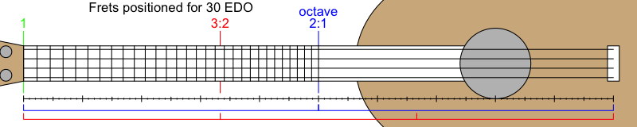

   First, determine the interval (in cents) of an exact 3:2 ratio. (*Notice, the calculation below suggests that a standard 12-EDO system is only ~2 cents away from a perfect 3:2 ratio when playing an interval of 7 [semitones](https://en.wikipedia.org/wiki/Semitone). This is a compelling reason to use [12 EDO](https://en.wikipedia.org/wiki/12_equal_temperament).*)

   $$I_\text{exact} ~=~ 1200\cdot\log_2\left(\frac{3}{2}\right) ~=~ 701.9550009$$

   Determine the best [fret](https://en.wikipedia.org/wiki/Fret) on the 30-EDO guitar to approximate a 3:2 ratio (after playing an open string) by [rounding](https://en.wikipedia.org/wiki/Rounding#Rounding_to_the_nearest_integer) a logarithmic function.

   $$x ~=~ \text{round} \left(30\cdot \log_2\left(\frac{3}{2}\right) \right)$$
   Then, determine the ratio of frequencies between an open string and the $x$th fret on the 30-EDO guitar. The ratio should be near 1.5, but a bit off.

   $$r = 2^{x/30}$$

   Calculate the cents of the interval between the open string and the $x$th fret.

   $$I_{\text{fret}} = 1200 \cdot \log_2(r)$$

   Finally, determine the absolute difference.

   $$\text{answer} = \left|I_{\text{fret}} - I_{\text{exact}}\right|$$

   Your answer can be rounded to the nearest cent.

#### Question

5. When the ratio between two [fundamental frequencies](https://en.wikipedia.org/wiki/Fundamental_frequency) is near 3:2, musicians call the interval a “fifth”, named from playing the first and fifth notes in a classical [diatonic scale](https://en.wikipedia.org/wiki/Diatonic_scale). Somewhat annoyingly, [equal temperament](https://en.wikipedia.org/wiki/Equal_temperament) does not allow for a ratio of exactly 3:2. Some equal temperaments get closer than others. Let’s investigate how close [40 EDO](https://en.wikipedia.org/wiki/Equal_temperament#Various_equal_temperaments) can get to an [exact 3:2 ratio of frequencies](https://en.wikipedia.org/wiki/Just_intonation). We will report the “distance” in cents.

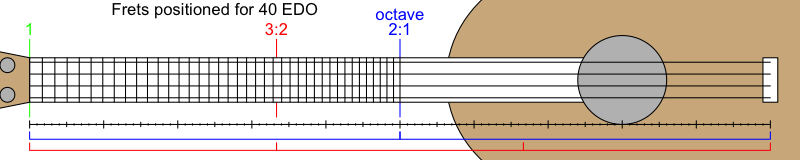

   First, determine the interval (in cents) of an exact 3:2 ratio. (*Notice, the calculation below suggests that a standard 12-EDO system is only ~2 cents away from a perfect 3:2 ratio when playing an interval of 7 [semitones](https://en.wikipedia.org/wiki/Semitone). This is a compelling reason to use [12 EDO](https://en.wikipedia.org/wiki/12_equal_temperament).*)

   $$I_\text{exact} ~=~ 1200\cdot\log_2\left(\frac{3}{2}\right) ~=~ 701.9550009$$

   Determine the best [fret](https://en.wikipedia.org/wiki/Fret) on the 40-EDO guitar to approximate a 3:2 ratio (after playing an open string) by [rounding](https://en.wikipedia.org/wiki/Rounding#Rounding_to_the_nearest_integer) a logarithmic function.

   $$x ~=~ \text{round} \left(40\cdot \log_2\left(\frac{3}{2}\right) \right)$$
   Then, determine the ratio of frequencies between an open string and the $x$th fret on the 40-EDO guitar. The ratio should be near 1.5, but a bit off.

   $$r = 2^{x/40}$$

   Calculate the cents of the interval between the open string and the $x$th fret.

   $$I_{\text{fret}} = 1200 \cdot \log_2(r)$$

   Finally, determine the absolute difference.

   $$\text{answer} = \left|I_{\text{fret}} - I_{\text{exact}}\right|$$

   Your answer can be rounded to the nearest cent.

#### Question

6. When the ratio between two [fundamental frequencies](https://en.wikipedia.org/wiki/Fundamental_frequency) is near 3:2, musicians call the interval a “fifth”, named from playing the first and fifth notes in a classical [diatonic scale](https://en.wikipedia.org/wiki/Diatonic_scale). Somewhat annoyingly, [equal temperament](https://en.wikipedia.org/wiki/Equal_temperament) does not allow for a ratio of exactly 3:2. Some equal temperaments get closer than others. Let’s investigate how close [32 EDO](https://en.wikipedia.org/wiki/Equal_temperament#Various_equal_temperaments) can get to an [exact 3:2 ratio of frequencies](https://en.wikipedia.org/wiki/Just_intonation). We will report the “distance” in cents.

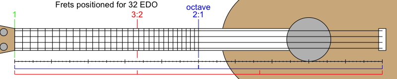

   First, determine the interval (in cents) of an exact 3:2 ratio. (*Notice, the calculation below suggests that a standard 12-EDO system is only ~2 cents away from a perfect 3:2 ratio when playing an interval of 7 [semitones](https://en.wikipedia.org/wiki/Semitone). This is a compelling reason to use [12 EDO](https://en.wikipedia.org/wiki/12_equal_temperament).*)

   $$I_\text{exact} ~=~ 1200\cdot\log_2\left(\frac{3}{2}\right) ~=~ 701.9550009$$

   Determine the best [fret](https://en.wikipedia.org/wiki/Fret) on the 32-EDO guitar to approximate a 3:2 ratio (after playing an open string) by [rounding](https://en.wikipedia.org/wiki/Rounding#Rounding_to_the_nearest_integer) a logarithmic function.

   $$x ~=~ \text{round} \left(32\cdot \log_2\left(\frac{3}{2}\right) \right)$$
   Then, determine the ratio of frequencies between an open string and the $x$th fret on the 32-EDO guitar. The ratio should be near 1.5, but a bit off.

   $$r = 2^{x/32}$$

   Calculate the cents of the interval between the open string and the $x$th fret.

   $$I_{\text{fret}} = 1200 \cdot \log_2(r)$$

   Finally, determine the absolute difference.

   $$\text{answer} = \left|I_{\text{fret}} - I_{\text{exact}}\right|$$

   Your answer can be rounded to the nearest cent.

#### Question

7. When the ratio between two [fundamental frequencies](https://en.wikipedia.org/wiki/Fundamental_frequency) is near 3:2, musicians call the interval a “fifth”, named from playing the first and fifth notes in a classical [diatonic scale](https://en.wikipedia.org/wiki/Diatonic_scale). Somewhat annoyingly, [equal temperament](https://en.wikipedia.org/wiki/Equal_temperament) does not allow for a ratio of exactly 3:2. Some equal temperaments get closer than others. Let’s investigate how close [36 EDO](https://en.wikipedia.org/wiki/Equal_temperament#Various_equal_temperaments) can get to an [exact 3:2 ratio of frequencies](https://en.wikipedia.org/wiki/Just_intonation). We will report the “distance” in cents.

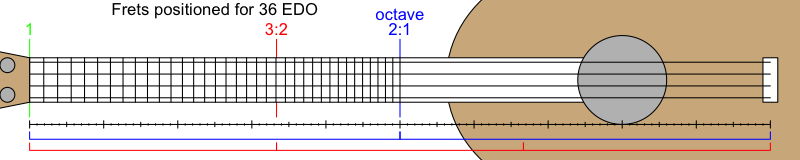

   First, determine the interval (in cents) of an exact 3:2 ratio. (*Notice, the calculation below suggests that a standard 12-EDO system is only ~2 cents away from a perfect 3:2 ratio when playing an interval of 7 [semitones](https://en.wikipedia.org/wiki/Semitone). This is a compelling reason to use [12 EDO](https://en.wikipedia.org/wiki/12_equal_temperament).*)

   $$I_\text{exact} ~=~ 1200\cdot\log_2\left(\frac{3}{2}\right) ~=~ 701.9550009$$

   Determine the best [fret](https://en.wikipedia.org/wiki/Fret) on the 36-EDO guitar to approximate a 3:2 ratio (after playing an open string) by [rounding](https://en.wikipedia.org/wiki/Rounding#Rounding_to_the_nearest_integer) a logarithmic function.

   $$x ~=~ \text{round} \left(36\cdot \log_2\left(\frac{3}{2}\right) \right)$$
   Then, determine the ratio of frequencies between an open string and the $x$th fret on the 36-EDO guitar. The ratio should be near 1.5, but a bit off.

   $$r = 2^{x/36}$$

   Calculate the cents of the interval between the open string and the $x$th fret.

   $$I_{\text{fret}} = 1200 \cdot \log_2(r)$$

   Finally, determine the absolute difference.

   $$\text{answer} = \left|I_{\text{fret}} - I_{\text{exact}}\right|$$

   Your answer can be rounded to the nearest cent.

#### Question

8. When the ratio between two [fundamental frequencies](https://en.wikipedia.org/wiki/Fundamental_frequency) is near 3:2, musicians call the interval a “fifth”, named from playing the first and fifth notes in a classical [diatonic scale](https://en.wikipedia.org/wiki/Diatonic_scale). Somewhat annoyingly, [equal temperament](https://en.wikipedia.org/wiki/Equal_temperament) does not allow for a ratio of exactly 3:2. Some equal temperaments get closer than others. Let’s investigate how close [6 EDO](https://en.wikipedia.org/wiki/Equal_temperament#Various_equal_temperaments) can get to an [exact 3:2 ratio of frequencies](https://en.wikipedia.org/wiki/Just_intonation). We will report the “distance” in cents.

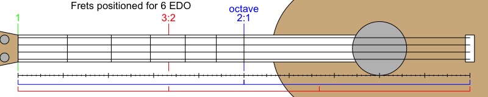

   First, determine the interval (in cents) of an exact 3:2 ratio. (*Notice, the calculation below suggests that a standard 12-EDO system is only ~2 cents away from a perfect 3:2 ratio when playing an interval of 7 [semitones](https://en.wikipedia.org/wiki/Semitone). This is a compelling reason to use [12 EDO](https://en.wikipedia.org/wiki/12_equal_temperament).*)

   $$I_\text{exact} ~=~ 1200\cdot\log_2\left(\frac{3}{2}\right) ~=~ 701.9550009$$

   Determine the best [fret](https://en.wikipedia.org/wiki/Fret) on the 6-EDO guitar to approximate a 3:2 ratio (after playing an open string) by [rounding](https://en.wikipedia.org/wiki/Rounding#Rounding_to_the_nearest_integer) a logarithmic function.

   $$x ~=~ \text{round} \left(6\cdot \log_2\left(\frac{3}{2}\right) \right)$$
   Then, determine the ratio of frequencies between an open string and the $x$th fret on the 6-EDO guitar. The ratio should be near 1.5, but a bit off.

   $$r = 2^{x/6}$$

   Calculate the cents of the interval between the open string and the $x$th fret.

   $$I_{\text{fret}} = 1200 \cdot \log_2(r)$$

   Finally, determine the absolute difference.

   $$\text{answer} = \left|I_{\text{fret}} - I_{\text{exact}}\right|$$

   Your answer can be rounded to the nearest cent.